```python
import torch
from PIL import Image
import numpy as np
import matplotlib.pyplot as plt
import torch.nn as nn
import torch.nn.functional as F
import torchvision
%matplotlib inline
import math as math
import cv2
from numpy import meshgrid
from scipy.signal import convolve, convolve2d, correlate2d
import random
```

# **TASK 1 - MNIST 0-100 (101 Classes)**

# Downloading and loading the MNIST dataset

```python
import keras
from keras.datasets import mnist
(x_train, y_train), (x_test, y_test) = mnist.load_data()
```

# Showing 5 samples of each class (0-9), With proper titles and the correct color map

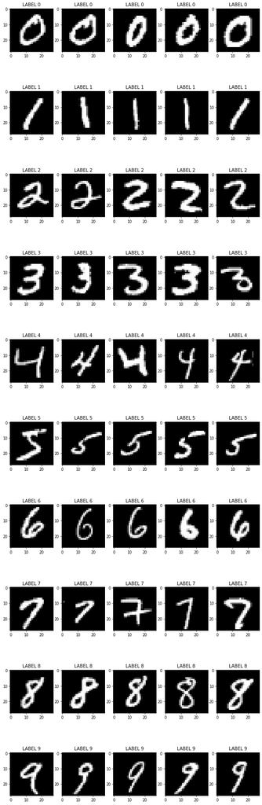

```python
train_filter = []
test_filter = []
n = 0
plt.figure(figsize=(12, 40), dpi=60)
for i in range(10):
  x = np.where((y_train == i ) )
  y = np.where((y_test == i))
  train_filter.append(x)
  test_filter.append(y)
  for j in range(5):
    plt.subplot(10, 5, n+1)
    n += 1
    plt.title('LABEL {digit}'.format(digit=i))
    plt.imshow(x_train[x][j], 'gray')
```

# Concating 3 images to 1

```python
def concat_image(im1, im2, im3):
  res = np.zeros((28, 28*3))
  res[:,:28] = im1
  res[:, 28:56] = im2
  res[:, 56:84] = im3
  return res
```

# Creating the new Data Set

```python
sample_num = 4000
n=0
my_data = np.zeros((28, 28*3, sample_num * 101))
lables = np.zeros((sample_num*101))
for i in range(1):
  for j in range(10):
    for l in range(10):
      for k in range(sample_num):
        img = concat_image(x_train[train_filter[i]][k], x_train[train_filter[j]][k], x_train[train_filter[l]][k])
        my_data[:, :, n] = img
        lables[n] = i*100 + j*10 + l
        n += 1
for i in range(sample_num):
  img = concat_image(x_train[train_filter[1]][i], x_train[train_filter[0]][k], x_train[train_filter[0]][k])
  my_data[:, :, (sample_num * 100) + i ] = img
  lables[(sample_num * 100) + i] = 100
```

```python
def rotate_coords(x, y, theta, ox, oy):
    s, c = np.sin(theta), np.cos(theta)
    x, y = np.asarray(x) - ox, np.asarray(y) - oy
    return x * c - y * s + ox, x * s + y * c + oy

def rotate_meshgrid(src, theta):
    oy, ox = src.shape[0]//2, src.shape[1]//2
    fill = 1
    theta = math.radians(theta)
    sh, sw = src.shape
    cx, cy = rotate_coords([0, sw, sw, 0], [0, 0, sh, sh], theta, ox, oy)

    dw, dh = sw, sh

    dx, dy = np.meshgrid(np.arange(dw), np.arange(dh))
    sx, sy = rotate_coords(dx, dy, -theta, ox, oy)
    sx, sy = sx.round().astype(int), sy.round().astype(int)

    mask = (0 <= sx) & (sx < sw) & (0 <= sy) & (sy < sh)
    res = np.zeros_like(src)
    res[dy[mask], dx[mask]] = src[sy[mask], sx[mask]]

    res[dy[~mask], dx[~mask]] = fill

    return res
```

```python
class augmentation:
   def __init__(self, img):
        self.img = np.copy(img)

   def Flip_img(self):
      if np.random.randint(2, size = 1) == 1:
        img_flipped = self.img[:, ::-1]  # flip horizontally
      else:
        img_flipped = self.img[::-1, :]# flip vertically

      return img_flipped

   def Rotate_img(self, angle):
      img = self.img
      rotate_img = rotate_meshgrid (img, angle) # using the rotate function from above

      return rotate_img


   def Gaussian_blur(self, sigma, kernel_size):
     range = 1
     span = np.linspace( - range , range, kernel_size )
     x, y = np.meshgrid(span, span)
     gaussian_blur = (( 1 / (2 * np.pi * sigma**2) )*
     np.exp(- (x**2 + y**2) / (2 * sigma**2)))
     gausian_filter =  gaussian_blur / gaussian_blur.sum()

     blured_img = convolve2d(self.img, gausian_filter, 'same')

     return blured_img


   def Median_Blur(self, kernel_size):
     img = np.copy(self.img)

     n, n = kernel_size , kernel_size
     paddingH = int(np.ceil(( kernel_size) / 2 ) -1 )
     paddingW = int(np.ceil(( kernel_size) / 2 ) -1 )

     median_img = np.zeros_like(img)
     img_padded = np.pad(img, [paddingH, paddingW])

     for i in range(median_img.shape[0]):
      for j in range(median_img.shape[1]):
        median_img[i, j]= np.median(img_padded[i:i + n, j:j + n])

     return median_img

   def Zoom (self, z_x = 1, z_y = 1):
     h, w = self.img.shape[0],  self.img.shape[1]
     H_C, W_C = h/2, w/2
     matrix = np.array([(z_x, 0), (0, z_y)])
     m_h, m_w = meshgrid(np.arange(h), np.arange(w))
     w_moved, h_moved = m_w - W_C, m_h - H_C

     new_w = matrix[0, 0] * w_moved + W_C
     new_h = matrix[1, 1] * h_moved + H_C
     new_w, new_h = new_w.round().astype(int), new_h.round().astype(int)

     cond = (new_h < h ) & (new_h >= 0) & (new_w < w) & (new_w >= 0)
     res = np.zeros_like(self.img)
     res[m_h[cond], m_w[cond]] = self.img[new_h[cond], new_w[cond]]

     return res

   def Crop(self):
     img_cropped = self.img[ 50: 300, 60: 270 ]
     return img_cropped
   def sharpening(self):
     a = 0.5
     d = np.array(([0, 0 ,0], [0, 1, 0], [0, 0, 0]), dtype = 'float')
     Lap = np.array(([0, -1 ,0], [-1, 4, -1], [0, -1, 0]), dtype = 'float')
     sharp = d + a * Lap
     img_sharpening = np.abs(convolve2d(self.img, sharp))

     return img_sharpening

   def Ten_aug(self) :
     img_flipped =self.Flip_img()
     img_guas = self.Gaussian_blur(0.5, 5)
     img_median =self.Median_Blur(5)
     img_roteted = self.Rotate_img(90)
     img_zoomed = self.Zoom(1.5, 1.5)
     img_cropped = self.Crop()
     img_sharpened = self.sharpening()
     img_zoomed2 = self.Zoom(0.5, 0.5)
     img_flipped2 =self.Flip_img()
     img_roteted2 = self.Rotate_img(270)
     l1 = [(img_flipped,'image flipped'), (img_roteted,'image rotated'), (img_zoomed,'image zoomed'),
           (img_cropped,'image cropped'), (img_zoomed2,'image zoomed2 '), (img_flipped2,'image flipped2'),
          (img_roteted2,'image rotated2'),(img_guas, 'image gause'), (img_median,'image median b'), (img_sharpened,'image sharpened')]
     return l1
```

# *SHOWING SOME RESULTS OF THE AUGMENTATIONS*

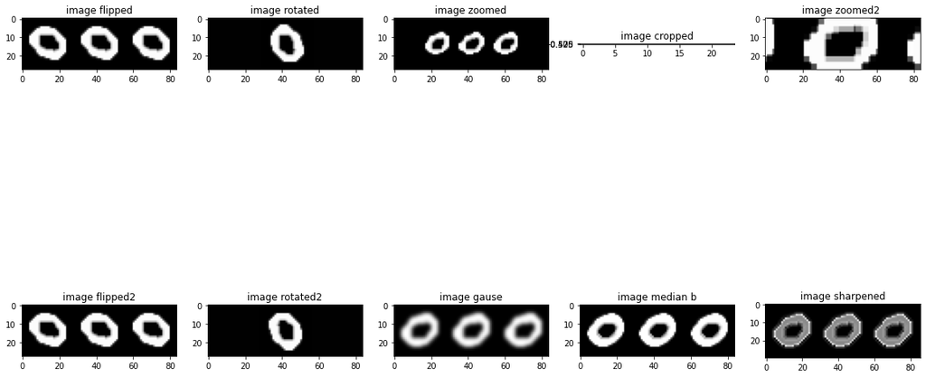

```python
img = my_data[:,:,990]
plt.figure(figsize=(20, 12))
s= augmentation(img)
images = s.Ten_aug()
for i in range(10):
  image , label = images[i]
  plt.subplot(2, 5, i+1)
  plt.title('{str}'.format(str= label))
  plt.imshow(image, 'gray')
```

# *Conclusion*

- As we can see, Some of the augmentations are applicable and some are not
- Not Applicable Augmentations:
  1. Flip image - our data is numbers, flipping the numbers will not be good to our lerning process
  2. Crop image - cropping the numbers is not good , loosing a lot of information of the image
  3. rotate image - like flipping the image , rotation of an image make the numbers not understandable towards it's label
  4. zoom_in image - also here like in cropping the image when you zoom in the iamge you loose information .
- Applicable Augmentations:
  1. zoom_out image - zooming out needs to be in cirtain range , you can't zoom out to much , But zooming out is good to create new images for the data
  2. Gaussian blur image
  3. Median blur image
  4. Sharpened image

# *10 new augmentations*

### 1.*Laplacian_Filter*

### 2.*box_blur*

### 3.*sobel_x*

### 4.*sobel_y*

### 5.*contrast*

### 6.*Translation*

### 7.*Guassian Noise*

### 8.*High Pass Filter*

### 9.*Averaging*

### 10.*Random Line*

```python
def Laplacian_Filter(img):
  return cv2.Laplacian(img,cv2.CV_64F)

def box_blur(img):
  return cv2.boxFilter(img, -1, (3, 3))

def sobel_x(img):
  return cv2.Sobel(img,cv2.CV_64F,1,0,ksize=5)

def sobel_y(img):
  return cv2.Sobel(img,cv2.CV_64F,0,1,ksize=5)

def contrast(img):
  array_alpha = np.array([4.25])
  array_beta = np.array([-300.0])
  for i in range(28):
  # add a beta value to every pixel
    cv2.add(img[:,i], array_beta, img[:,i])
    cv2.add(img[i,:], array_beta, img[i,:])
  # multiply every pixel value by alpha
    cv2.multiply(img[i,:], array_alpha, img[i,:])
    cv2.multiply(img[:,i], array_alpha, img[:,i])
  return img

def Translation(img):
  rows,cols = img.shape
  M = np.float32([[1,0,2.5],[0,1,2.5]])
  dst = cv2.warpAffine(img,M,(cols,rows))
  return dst
def add_guassian_noise(img: np.ndarray, mean = 0.1, sigma = 0.7) -> np.ndarray:
  gauss = np.random.normal(mean,sigma, img.shape)
  noised_image = img + gauss
  noised_image = noised_image.astype(np.uint8)
  return noised_image
def High_Pass_Filter(img):
  s = augmentation(img)
  blured = s.Gaussian_blur(10, 14)
  HPF = img - blured
  return HPF
def  averaging(img):
   kernel = np.ones((4,4), np.float32)/16
  # Apply convolution between image and the  Kernel
   dst = cv2.filter2D(img,-1, kernel)
   return dst
def Random_Line(img):
  ex = img.copy()
  row = np.random.randint(8, 25)
 # row1 = row + 1
  for i in range(84):
    ex[row,i] = 0
    #ex[row1,i] = 0
  return ex
```

## Showing the new Augmentations

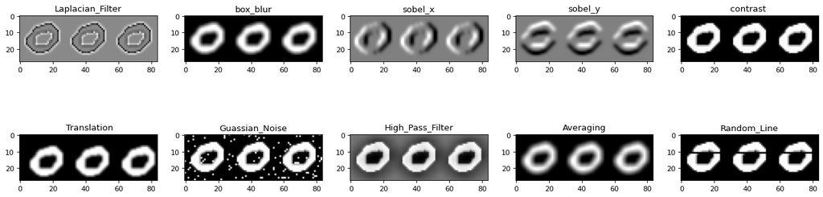

```python
img = my_data[:,:,990]
img_LF =Laplacian_Filter(img)
img_bxb = box_blur(img)
img_sx =sobel_x(img)
img_sy = sobel_y(img)
img_ct = contrast(img)
img_Tr = Translation(img)
img_GN = add_guassian_noise(img)
img_HPF = High_Pass_Filter(img)
img_Av = averaging(img)
img_RL =Random_Line(img)
images = [(img_LF,'Laplacian_Filter'), (img_bxb,'box_blur'), (img_sx,'sobel_x'),
           (img_sy,'sobel_y'), (img_ct,'contrast '), (img_Tr,' Translation'),
          (img_GN,'Guassian_Noise'),(img_HPF, 'High_Pass_Filter'), (img_Av,'Averaging'), (img_RL,'Random_Line')]
plt.figure(figsize=(20, 30), dpi=80)
for i in range(10):
  image , label = images[i]
  plt.subplot(10, 5, i+1)
  plt.title('{str}'.format(str= label))
  plt.imshow(image, 'gray')
```

# *Demonstrating the variability of the new dataset*

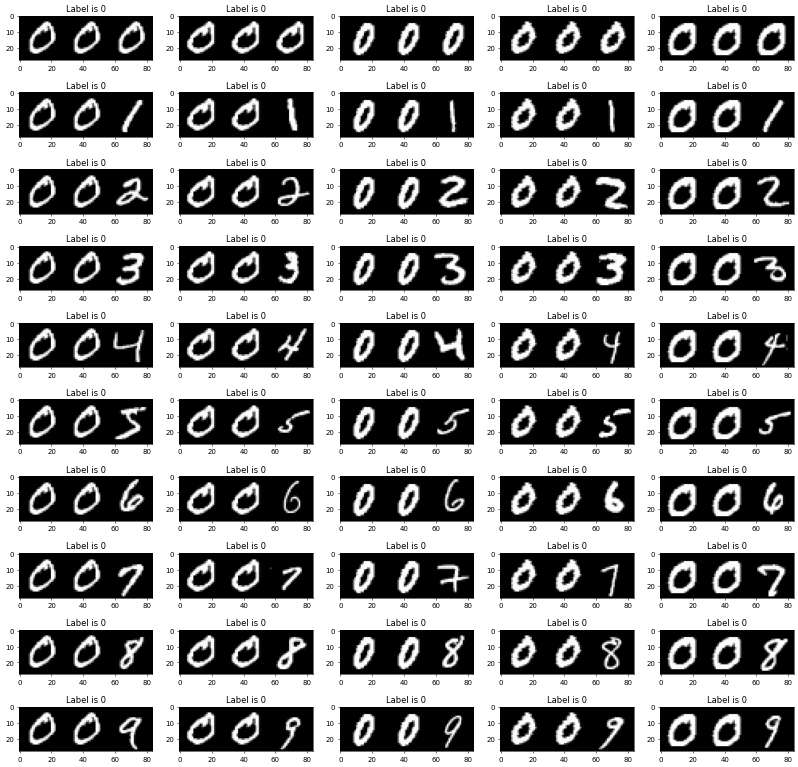

```python
n = 0
plt.figure(figsize=(20, 20), dpi=50)
for i in range(10):
  for j in range(5):
    plt.subplot(10, 5, n+1)
    n +=  1
    plt.title('Label is {label}'.format(label=int(lables[i*10+j])))
    plt.imshow(my_data[:,:,i*4000 + j],'gray')
```

# **Summary for Task 1**

- Download and load the MNIST dataset and then looked at the images and understand them - shape
- Understand how to create one image of 3 digits numbers from 3 different digit image, and then created my data set with labels
- Used the augmantaion from lab3 on the new data set , explained above about the result - which augmentations are applicable to this specific dataset, which are not and why.
- implement new augmentaions - good augmentations to this spesific data set , Used the new augmentaions and showed some results
- And finally demonstratede the variability of the new dataset